# 2. Beadandó

Somogyi Áron - F2FJYM

2022-12-16

## Bevezetés

A következő feladatban a magyar közbeszerzések 2005-2021 közötti adatbázisát fogom használni. A változók közül a következőket fogom vizsgálni: közbeszerzés éve (year_raw), beérkezett ajánlatok száma (cbidders_raw), győztes neve (wname_raw), szerződés típusa (contract_type_raw), szeződés szerinti nettó érték (ncvalue), nettó becsült érték (nevalue), utóbbi kettő közül a nettó becsült értékre fókuszálva. Továbbá: szektor (sector), és, hogy európai uniós beruházás-e (eu). Az adatbázis mérete hatalmas, így rengeteg egyéb változót kiszűrtem, illetve hosszas adattisztítás után a megmaradtakat amennyire tudtam leegyszerűsítettem. A célom nem korrupciókutatás a következő adatbázis használata során, hanem egyszerűen az adatbázis bemutatása.

## Leíró Statisztika

|  | vars | n | mean | sd | median | trimmed | mad | min | max | range | skew | kurtosis | se |
| --- | --- | --- | --- | --- | --- | --- | --- | --- | --- | --- | --- | --- | --- |
| year_raw | 1 | 268799 | 2014.252676 | 4.226068e+00 | 2014.00000 | 2014.353356 | 5.93040 | 2005.00 | 2021.0 | 16.0 | -0.1663634436 | -0.9403923 | 8.151220e-03 |
| cbidders_raw | 2 | 266907 | 5.385179 | 7.995247e+01 | 2.00000 | 2.505098 | 1.48260 | 0.00 | 9288.0 | 9288.0 | 68.4571007914 | 5789.9699737 | 1.547576e-01 |
| wname_raw* | 3 | 266708 | 33772.810227 | 1.904911e+04 | 33896.00000 | 33757.609515 | 24471.79560 | 1.00 | 67034.0 | 67033.0 | 0.0005240873 | -1.1989005 | 3.688558e+01 |
| pp_type_raw* | 4 | 238394 | 72.067070 | 3.050706e+01 | 81.00000 | 75.037454 | 26.68680 | 1.00 | 136.0 | 135.0 | -0.6513895249 | -1.0374495 | 6.248168e-02 |
| agreement_raw* | 5 | 20230 | 7.199011 | 4.461660e+00 | 7.00000 | 7.249506 | 7.41300 | 1.00 | 14.0 | 13.0 | -0.1641011709 | -1.8013204 | 3.136885e-02 |
| contract_type_raw* | 6 | 255087 | 1.880076 | 8.341782e-01 | 2.00000 | 1.850096 | 1.48260 | 1.00 | 3.0 | 2.0 | 0.2276586456 | -1.5267374 | 1.651637e-03 |
| ncvalue | 7 | 262252 | 221.286764 | 2.208095e+03 | 17.85985 | 32.673161 | 23.30140 | 0.01 | 266854.7 | 266854.7 | 27.7096338349 | 1398.6059243 | 4.311798e+00 |
| nevalue | 8 | 188487 | 282.364532 | 2.424812e+03 | 23.00000 | 41.789282 | 28.94035 | 0.01 | 250000.0 | 250000.0 | 24.0171574026 | 1034.4569865 | 5.585183e+00 |
| sector* | 9 | 266448 | 4.699292 | 1.997859e+00 | 4.00000 | 4.539060 | 1.48260 | 1.00 | 8.0 | 7.0 | 0.7077887332 | -1.0345943 | 3.870425e-03 |
| eu* | 10 | 264289 | 1.350862 | 4.772408e-01 | 1.00000 | 1.313579 | 0.00000 | 1.00 | 2.0 | 1.0 | 0.6249981962 | -1.6093833 | 9.283206e-04 |

Az adatbázisban 268799 elem található (a hiányzó értékek miatt a táblázatban ez nem mindenhol köszön vissza).

### Ajánlatok száma

Ha ránézünk az ajánlattevők számára, azt láthatjuk, hogy az adatok alapján az összes közbeszerzés (legalább) felére maximum kettő ajánlat érkezett. Átlagosan pedig 5.39 ajánlat született egy-egy közbeszerzésre. A legtöbb ajánlattal rendelkező közbeszerznél 9288-at számolhatunk míg volt olyan, amelynél nullát. Megoszlása tehát nem normális, erősen jobbra elnyúló.

Elkészítettem egy Pareto-ábrát, amely megmutatja ennek a változónak tényleges megoszlását, illetve kummulatív megoszlását. Az ábráról könnyen leolvasható, hogy az esetek kb. 80 százalékában 4, vagy kevesebb ajánlat; 10 ajánlatnál több, pedig kevesebb, mint az esetek 10 százalékában lett téve.

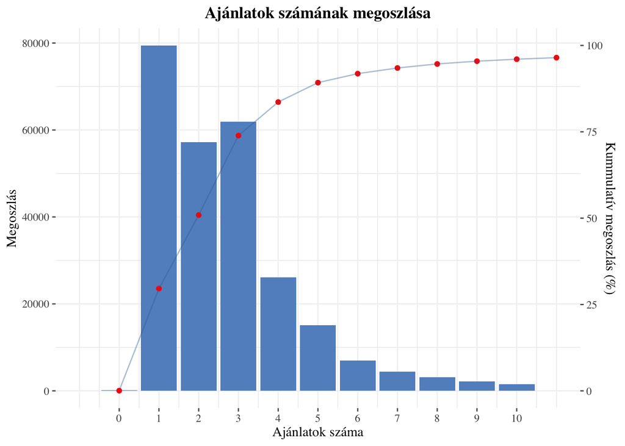

Azt is megfigyelhetjük, hogy a nagy értékű beruházásokra mennyien tettek ajánlatot. A következő ábrát lekorlátoztam 50 milliárdos beruházásokig, de így is szemlélteti, hogy a nagyobb összegekre kevesebben pályáznak. Ugyanez a megállapítás igaz, mindegy, hogy EU-s beruházás, vagy állami.

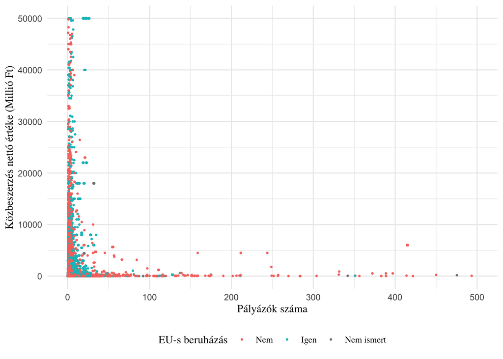

### Hogy nézett ki a közbeszerzések összértékének éves megoszlása?

Leolvasható a következő ábrán, hogy a legkevesebb összértékű közbeszerzések 2011-ben történtek (talán kormányváltási konszolidáció miatt). Még ez is hatalmas összeg, közel ezermilliárd forint. A legnagyobb összeg ennek több, mint nyolcszorosa, a 2015-ös nyolcezer-milliárd forint.

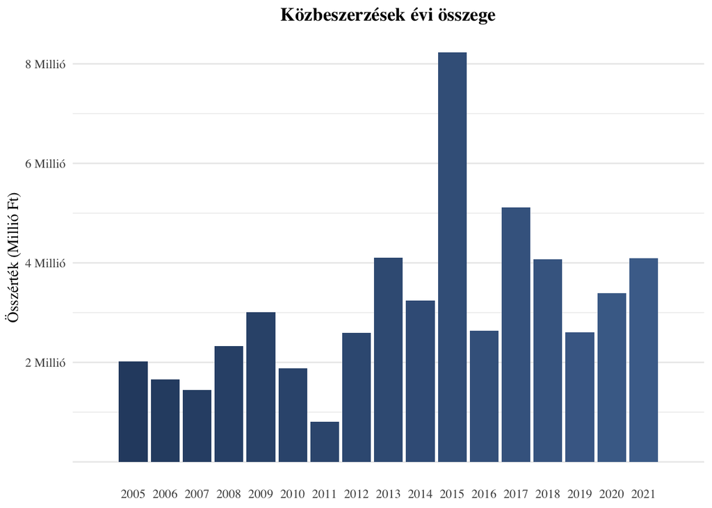

### Közbeszerzések éves megoszlása.

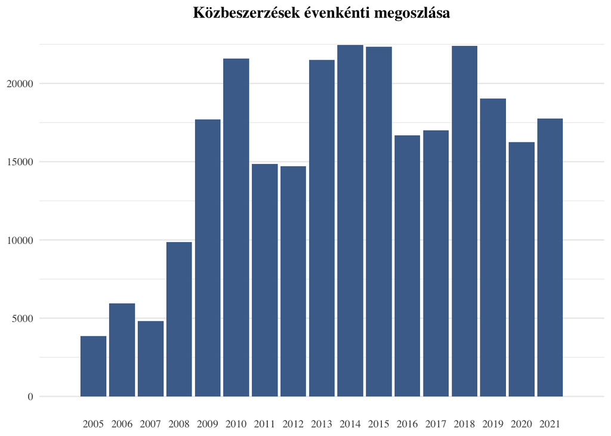

Nem mutat sok összefüggést tehát a beszerzések évenkénti értéke és az évenkénti darabszámuk.

### Nyertesek száma

A nyertesek számának éves megoszlását is elkészítettem. A következő ábrán látható, hogy mely évben hány különböző személy, vagy cég nyert közbeszerzést. Leolvasható, hogy 2005-ben kevesebb, mint 2500 különböző cég, vagy személy nyert közbeszerzést, ez körülbelül a 2008-as kormányválság, majd Bajnai-kormányzás alatt növekedni kezdett. A legmagasabb értéket a 2014-es évben vette fel, itt is és az ezt követő évben is 10000-nél valamivel több különböző jogi személy nyert közbeszerzést.

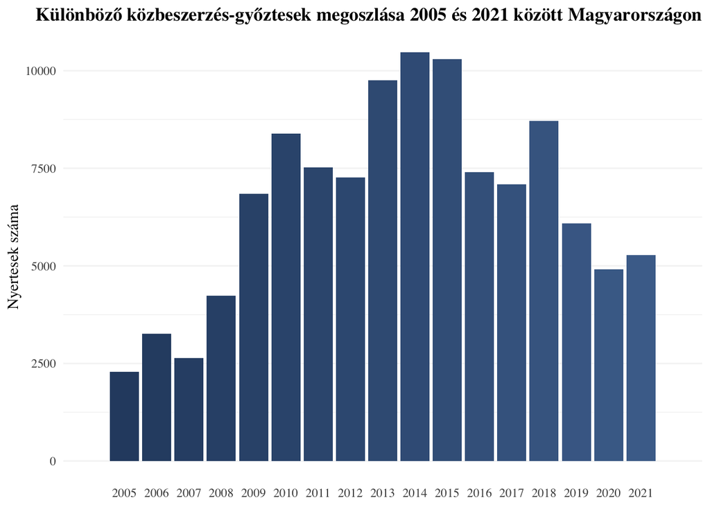

## Top 1%

A közbeszerzések becsült nettó értékének leíró statisztikái hatalmas kiugrásokról árulkodnak:

```
##      Min.   1st Qu.    Median      Mean   3rd Qu.      Max.
##      0.01      7.64     23.00    282.36     70.28 250000.00
```

Emiatt érdekelni kezdett a legmagasabb 1% kifizetés értéke, és ennek a részesedésnek az aránya az összes kifizetésből.

```
## [1] "A legnagyobb 1% kifizetés értéke (Millió Ft):  35594546.590464"
```

```
## [1] "Ennek aránya az összes kifizetésből:  66.8793309710436 %"
```

```
## [1] "Ennek a kettőnek aránya egy kördiagramon, ahol a türkiz szín jelenti a top 1 százalékot:"
```

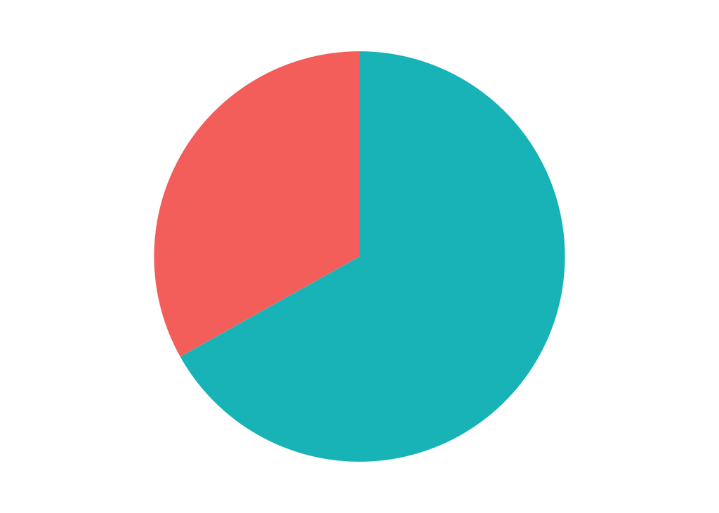

A legjobb 1% közbeszerzésnek valamelyest hasonló megoszlása van, mint az összes közbeszerzés évenkénti megoszlásának. Kivéve ez alól a 2005-2008-2009-es évek, ahol a drága beruházások jóval nagyobb arányban voltak jelen arányaiban, mint a későbbi években. 2010-2011-2012-ben pedig kevesebb beruházás került ebbe a top kategóriába, mint ahogy ugyanezek az évek aránylanak az összes közbeszerzéshez.

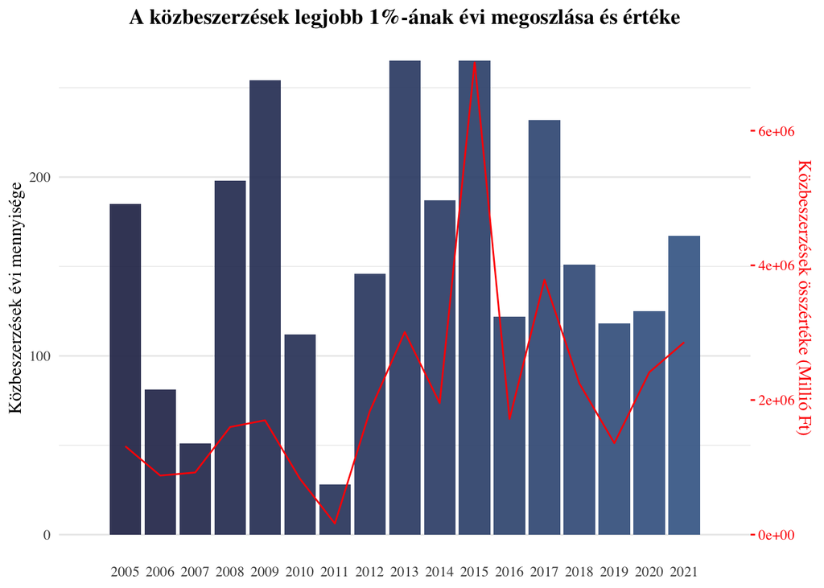

## Szektorok megoszlása

A következő ábrán látható a szektorok megoszlása az általuk szerzett beszerzések becsült értéke alapján.

Mivel a közbeszerzések döntő része milliós nagyságrendű volt, amelyhez képest viszont nagy kiugrás a (sok)milliárdos beszerzés, logaraitmikus megoszlást készítettem, simított megoszlás-ábrán. Az első az egymáshoz való viszonyítást segíti. Ezen látszódik, hogy jellemzően az 1-es szektorban való beruházások esetén számíthatunk a legkevesebb pénzre, míg a 7-es és 5-ös szektorban számottevő a tíz-százmilliárdos befektetés is. (Megjegyzés: az első ábrán a nyolcas szektor a Nem ismert kategória.)

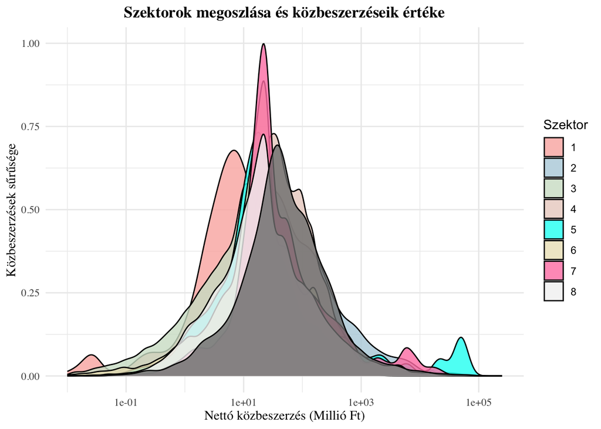

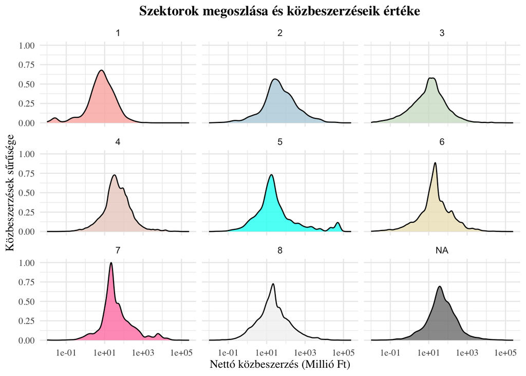

## Vállalatok sikeressége

A tíz legsikeresebb vállatot kiválogattam, az általuk megnyert közbeszerzések száma alapján:

```
##
##                     hartmann-rico hungaria kft.
##                                             870
##                      molnlycke health care kft.
##                                             803
##                             magyar aszfalt kft.
##                                             797
##                          johnson & johnson kft.
##                                             688
## euromedic-pharma gyogyszernagykereskedelmi zrt.
##                                             662
##                    swietelsky magyarorszag kft.
##                                             559
##                               duna aszfalt kft.
##                                             551
##                                   colas ut zrt.
##                                             504
##                                    immofix kft.
##                                             498
##                          baromfiudvar 2002 kft.
##                                             489
```

### Hartmann-Rico

Először a legsikeresebb vállalat, a Hartmann-Rico Hungária kft.sikerességét vizsgáltam meg. A vállalat növekvő tendenciát mutat elnyert közbeszerzések terén. 2016-ig a legtöbb évi 50 közbeszerzésről 2017-ben hirtelen közel 150 megrendelést kapott a kft. 2019-ben nyert legtöbbet, több, mint 150 közbeszerzést.

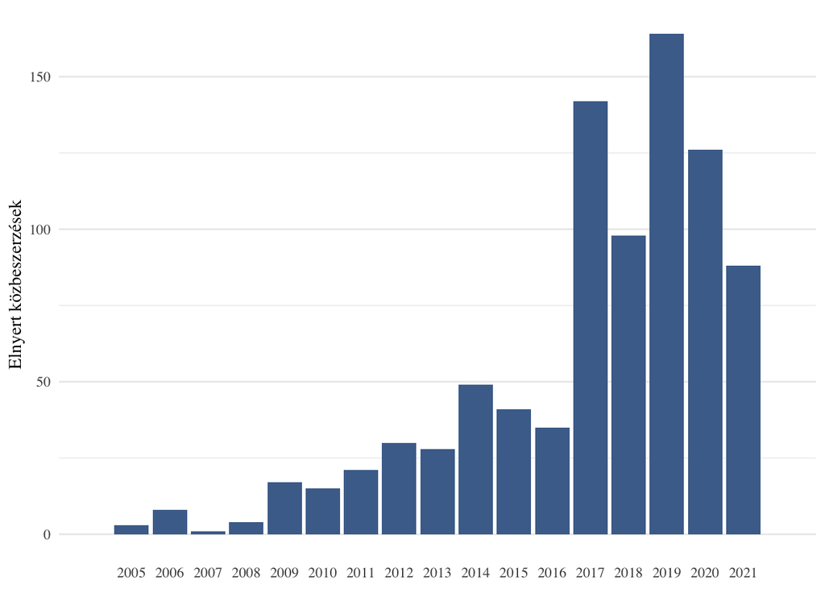

### Magyar Aszfalt - Duna Aszfalt

A tíz legsikeresebb cégben két aszfaltozó cég is bekerült, ezeknek a potenciális rivalizációjára (vagy oldalkötődésére) voltam kíváncsi.

A Magyar Aszfalt 2010-ig nyert nagy mennyiségű közbeszerzést (többek közt a hatalmas költségvetésű 2007-es autópályafelújítást). 2010-ben több, mint 250 beszerzést nyert, a Duna Aszfalt pedig ekkorra már úgyszintén több, mint 100 beszerzést tudhatott magáénak. 2013 volt az utolsó év, hogy a Magyar Aszfalt kft. közbeszerzést nyert, azóta csak a Duna Aszfalt kft. szerez közbeszerzést.

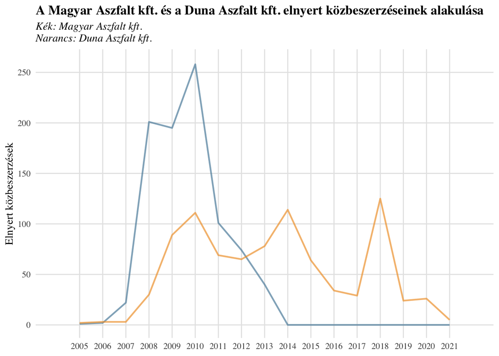

## Lezárás

Munkámban, mint írtam nem korrupciót vizsgáltam, csupán 16 év közbeszerzéseinek általános bemutatását, különböző-kisebb kérdések mentén kíséreltem meg különféle adatvizualizációs módszerekkel. Igyekeztem a lehető leg olvashatóbb-és érthetőbb ábrákat létrehozni, és ha ez sikerült, még érdekes adatokat is bemutatni rajta.